HGG-oncohistones project [[source](https://github.com/fungenomics/HGG-oncohistones/blob/master/R-4/code/03A-celltype_epigenomic_similarity.Rmd)]

# 03A - Epigenomic similarity between tumors & COO

Selin Jessa [selin.jessa@mail.mcgill.ca]

28 July, 2022

# 1 Configuration

Configuration of project directory & analysis outputs:

**Show full config**

```r
source(here("rr_helpers.R"))

# Set up outputs
message("Document index: ", doc_id)
```

```
## Document index: 03A
```

```r
# Specify where to save outputs
out        <- here("R-4/output", doc_id); dir.create(out, recursive = TRUE)
figout     <- here("R-4/figures", doc_id); dir.create(figout, recursive = TRUE)
cache      <- paste0(readLines(here("include/project_root.txt")), "R-4.1.2/", basename(here()), "/", doc_id, "/")
```

Outputs and figures will be saved at these paths, relative to project root:

```
## public/R-4/output/03A
```

```
## public/R-4/figures/03A
```

Setting a random seed:

```r
set.seed(100)
```

# 2 Overview

Here we'll examine the similarity between HGGs and PFAs to their respective cells-of-origin based on epigenomic data across genomic features.

For this analysis, we obtained Paired-Tag data for different histone modifications and corresponding cell type specific epigenome prifles from [Zhu et al, Nature Methods, 2021](https://doi.org/10.1038/s41592-021-01060-3).

# 3 Libraries

```r
library(here)

# For genome analysis / references
library(GenomicRanges)
library(plotgardener)
library(TxDb.Hsapiens.UCSC.hg19.knownGene)
library(org.Hs.eg.db)
library(TxDb.Mmusculus.UCSC.mm10.knownGene)
library(org.Mm.eg.db)
library(rtracklayer)

# general purpose
library(tidyr)
library(dplyr)
library(ggrepel)
library(ggrastr)
library(readr)
library(glue)
library(tibble)
library(ggplot2)
library(purrr)
library(pheatmap)
library(stringr)
library(fgsea)
library(icytobox)
library(cowplot)

source(here("include/style.R"))
source(here("R-4/code/functions/plotgardener_helpers.R"))
ggplot2::theme_set(theme_min())
```

# 4 Load metadata

Load the sample metadata for the project:

```r
meta      <- read_tsv(here("data/metadata/metadata_patient_samples_NGS.tsv"))
meta_chip <- read_tsv(here("data/metadata/metadata_chip_all.tsv"))
```

# 5 Load data

Import ChromHMM state calls from Zhu et al using `rtracklayer::import())`:

```r
# OPC is cluster 15 and ependymal is cluster 22
opc_chromhmm <- import(
    here("data/Paired-Tag/Zhu_2021/ChromHMM/15_8_segments.bed"))
epen_chromhmm <- import(
    here("data/Paired-Tag/Zhu_2021/ChromHMM/22_8_segments.bed"))

# subset to autosomes
chrs_keep <- paste0("chr", 1:29)
opc_chromhmm <- opc_chromhmm[seqnames(opc_chromhmm) %in% chrs_keep]
epen_chromhmm <- epen_chromhmm[seqnames(epen_chromhmm) %in% chrs_keep]

# load segment info
read_tsv(here("data/Paired-Tag/Zhu_2021/ChromHMM/README_segment.txt"))
```

| 2-Promoter-Weak | E1 |
| --- | --- |
| 1-Promoter-Active | E2 |
| 3-Enhancer-Active | E3 |
| 4-Enhancer-Poised | E4 |
| 7-No signal | E5 |
| 8-No signal-Gene Desert | E6 |
| 6-Heterochromatin-H3K9me3 | E7 |
| 5-Heterochromatin-H3K27me3 | E8 |

# 6 Get cell-type specific genomic regions

First, subset to active/inactive genomic regions for each cell type:

```r
active_states <- c("E1", "E2", "E3")
inactive_states <- c("E7", "E8")

opc_active   <- opc_chromhmm[(elementMetadata(opc_chromhmm)[, "name"] %in% active_states)]
opc_inactive <- opc_chromhmm[(elementMetadata(opc_chromhmm)[, "name"] %in% inactive_states)]

epen_active   <- epen_chromhmm[(elementMetadata(epen_chromhmm)[, "name"] %in% active_states)]
epen_inactive <- epen_chromhmm[(elementMetadata(epen_chromhmm)[, "name"] %in% inactive_states)]
```

```r
# regions active in OPC and inactive in epen
hits <- findOverlaps(opc_active, epen_inactive)
overlaps <- pintersect(opc_active[queryHits(hits)], epen_inactive[subjectHits(hits)])
length(overlaps)
```

```
## [1] 418
```

```r
percentOverlap <- width(overlaps) / width(opc_active[subjectHits(hits)])
hits <- hits[percentOverlap > 0.1]
opc_active_specific <- opc_active[queryHits(hits)]
length(opc_active_specific)
```

```
## [1] 416
```

```r
# regions active in epen and inactive in OPC
hits <- findOverlaps(epen_active, opc_inactive)
overlaps <- pintersect(epen_active[queryHits(hits)], opc_inactive[subjectHits(hits)])
length(overlaps)
```

```
## [1] 291
```

```r
percentOverlap <- width(overlaps) / width(epen_active[subjectHits(hits)])
hits <- hits[percentOverlap > 0.1]
epen_active_specific <- epen_active[queryHits(hits)]
length(epen_active_specific)
```

```
## [1] 291
```

```r
elementMetadata(opc_active_specific)$celltype <- "OPC"
elementMetadata(epen_active_specific)$celltype <- "Ependymal"
```

Load BED file of mm10 genes, and look for overlaps:

```r
mm10_genes_bed <- rtracklayer::import(here("data/ChIPseq/references/Ensembl.ensGene.mm10.collapsed.bed"))
mm10_genes_bed <- mm10_genes_bed[seqnames(mm10_genes_bed) %in% chrs_keep]

# add 5kb on either side
start(mm10_genes_bed) <- start(mm10_genes_bed) - 2500
# end(mm10_genes_bed)   <- end(mm10_genes_bed) + 5000

# find nearest gene for each OPC element
opc_nearest_genes_idx <- nearest(opc_active_specific, mm10_genes_bed)
opc_nearest_genes <- mm10_genes_bed[opc_nearest_genes_idx]
opc_nearest_genes_hg <- opc_nearest_genes$name %>% sapply(str_split, ":") %>%
    sapply(getElement, 2) %>%
    mm2hg() %>%
    unlist() %>%
    unique()

# how many?
length(unique(opc_nearest_genes$name))
```

```
## [1] 300
```

```r
# same thing for ependymal elements
epen_nearest_genes_idx <- nearest(epen_active_specific, mm10_genes_bed)
epen_nearest_genes <- mm10_genes_bed[epen_nearest_genes_idx]
length(unique(epen_nearest_genes$name))
```

```
## [1] 197
```

```r
epen_nearest_genes_hg <- epen_nearest_genes$name %>% sapply(str_split, ":") %>%
    sapply(getElement, 2) %>%
    mm2hg() %>%
    unlist() %>%
    unique()


# mm
epen_nearest_genes_mm <- epen_nearest_genes$name %>% sapply(str_split, ":") %>%
    sapply(getElement, 2) %>% unname() %>% unique()
opc_nearest_genes_mm <- opc_nearest_genes$name %>% sapply(str_split, ":") %>%
    sapply(getElement, 2) %>% unname() %>% unique()

(common_mm <- base::intersect(opc_nearest_genes_mm, epen_nearest_genes_mm))
```

```
## [1] "Cbx8"          "Rbfox1"        "6030443J06Rik"
```

```r
opc_nearest_genes_mm <- base::setdiff(opc_nearest_genes_mm, common_mm)
epen_nearest_genes_mm <- base::setdiff(epen_nearest_genes_mm, common_mm)

# hg
(common <- base::intersect(opc_nearest_genes_hg, epen_nearest_genes_hg))
```

```
## [1] "RBFOX1" "CBX8"   ""
```

```r
opc_nearest_genes_hg <- base::setdiff(opc_nearest_genes_hg, common)
epen_nearest_genes_hg <- base::setdiff(epen_nearest_genes_hg, common)

nearest_genes_hg_uniq <- c(opc_nearest_genes_hg,
                           epen_nearest_genes_hg)

length(nearest_genes_hg_uniq)
```

```
## [1] 413
```

```r
# make a dataframe to annotate
feature_anno <- bind_rows(
    data.frame("Feature"   =  opc_nearest_genes_hg,
               "Cell_type" = "OPC"),
    data.frame("Feature"   =  epen_nearest_genes_hg,
               "Cell_type" = "Ependymal"))

# save
save(opc_nearest_genes_mm, epen_nearest_genes_mm,
     opc_nearest_genes_hg, epen_nearest_genes_hg, nearest_genes_hg_uniq,
     feature_anno,
     file = glue("{out}/cell_type_specific_features.Rda"))
```

Next, we need to obtain the corresponding human features, quantify H3K27ac/H3K27me3/scATAC there, and then see first if the information in these features is enough to separate tumor types.

# 7 Evaluate samples at cell-type features

## 7.1 Format inputs

```r
data_chip_wide <- read_tsv(here("output/02/TABLE_promoter_H3K27ac_H3K27me3_per_sample.tsv"))
# reformat promoter H3K27ac to a matrix
promoter_mat <- data_chip_wide %>%
    select(-matches("Median|Z")) %>%
    select(gene_symbol, 7:ncol(.)) %>%
    filter(gene_symbol %in% nearest_genes_hg_uniq) %>%
    distinct(gene_symbol, .keep_all = TRUE) %>%
    tibble::column_to_rownames(var = "gene_symbol") %>%
    t()

# sanity checks
dim(promoter_mat)
```

```
## [1]  69 400
```

```r
length(unique(rownames(promoter_mat)))
```

```
## [1] 69
```

```r
nearest_genes_hg_uniq[!(nearest_genes_hg_uniq %in% data_chip_wide$gene_symbol)]
```

```
##  [1] "AC058822.1"   "AL592490.1"   "AC092329.3"   "ZNF66"        "AC115220.1"
##  [6] "AL359922.1"   "AC010615.4"   "AC005154.6"   "FP236240.1"   "CU639417.1"
## [11] "AL117339.5"   "FAM47E-STBD1" "MDFIC2"
```

```r
feature_anno <- feature_anno %>%
    filter(Feature %in% colnames(promoter_mat))

save(promoter_mat,
     feature_anno,
     file = glue("{out}/promoter_H3K27ac_H3K27me3_mat.Rda"))

dim(feature_anno)
```

```
## [1] 400   2
```

## 7.2 H3K27ac @ cell-type features

Next, we can verify that these features, which were selected by ChromHMM, do indeed correspond to high H3K27ac in the requisite cell type, and low in the other.

Load quantifications of promoter H3K27ac in OPC and ependymal cells using deeptools:

```r
mm10_promoters <- rtracklayer::import(here("data/ChIPseq/references/Ensembl.ensGene.mm10.collapsed.promoter5kb.bounded.bed")) %>%
    as.data.frame()
celltype_k27ac <- data.table::fread(here("R-4/output/03B/MBS_Ensembl.ensGene.mm10.collapsed.promoter5kb.tab"), data.table = FALSE)
colnames(celltype_k27ac) <- c("chr", "start", "end", "OPC", "Ependymal")

celltype_k27ac_anno <- celltype_k27ac %>%
    # don't join by start, because import does start+1
    left_join(mm10_promoters, by = c("chr" = "seqnames", "end" = "end")) %>%
    separate(name, into = c("ENSID", "symbol"), sep = ":")
```

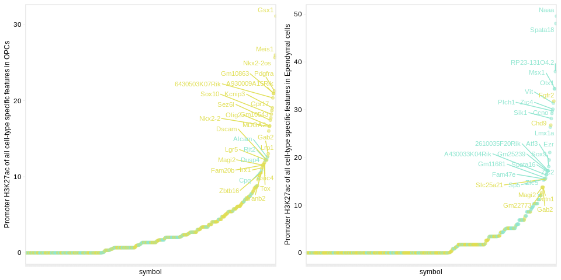

```r
celltype_k27ac_anno_df <- celltype_k27ac_anno %>%
    filter(symbol %in% c(opc_nearest_genes_mm, epen_nearest_genes_mm)) %>%
    mutate(Feature_type = case_when(
        symbol %in% opc_nearest_genes_mm ~ "OPC",
        symbol %in% epen_nearest_genes_mm ~ "Ependymal"
    )) %>%
    select(symbol, Feature_type, OPC, Ependymal) %>%
    distinct(symbol, .keep_all = TRUE)

p1 <- celltype_k27ac_anno_df %>%
    arrange(OPC) %>%
    mutate(symbol = factor(symbol, levels = unique(.$symbol))) %>%
    ggplot(aes(x = symbol, y = OPC)) +
    geom_point(stat = "identity", aes(colour = Feature_type), alpha = 0.5) +
    geom_text_repel(data = celltype_k27ac_anno_df %>% top_n(30, OPC),
                    aes(label = symbol, colour = Feature_type), size = 3, max.overlaps = 30) +
    scale_colour_manual(values = palette_type) +
    rotate_x() +
    theme(axis.text.x = element_blank()) +
    ylab("Promoter H3K27ac of all cell-type specific features in OPCs") +
    no_legend()

p2 <- celltype_k27ac_anno_df %>%
    arrange(Ependymal) %>%
    mutate(symbol = factor(symbol, levels = unique(.$symbol))) %>%
    ggplot(aes(x = symbol, y = Ependymal)) +
    geom_point(stat = "identity", aes(colour = Feature_type), alpha = 0.5) +
    geom_text_repel(data = celltype_k27ac_anno_df %>% top_n(30, Ependymal),
                    aes(label = symbol, colour = Feature_type), size = 3, max.overlaps = 30) +
    scale_colour_manual(values = palette_type) +
    rotate_x() +
    theme(axis.text.x = element_blank()) +
    ylab("Promoter H3K27ac of all cell-type specific features in Ependymal cells") +
    no_legend()

plot_grid(p1, p2, nrow = 1)
```

```r
save(celltype_k27ac_anno_df, file = glue("{out}/celltype_k27ac_anno_df.Rda"))
```

```r
discrim_features_mm <- c(celltype_k27ac_anno_df %>% top_n(20, OPC) %>% pull(symbol),
                         celltype_k27ac_anno_df %>% top_n(20, Ependymal) %>% pull(symbol))

discrim_features_hg <- discrim_features_mm %>% mm2hg() %>%
    unlist() %>%
    unique() %>%
    discard(. == "") %>%
    # make sure these features are present in tumors
    keep(. %in% feature_anno$Feature)
```

## 7.3 Tumors and cell lines (HGG and PFA)

In this analysis, we'll include all HGG and PFA tumors and cell lines:

```r
samples_1 <- meta_chip %>%
    filter(Group %in% c("HGG-H3.1/2K27M-Pons",
                        "HGG-H3.3K27M-Pons",
                        "HGG-H3.3K27M-Thalamus",
                        "PFA-EZHIP-PF",
                        "PFA-H3.1K27M-PF") &
               (Material == "Tumor" | CRISPR == "Parental") &
               !grepl("Nagaraja", Source)) %>%
    filter(Factor == "H3K27ac") %>%
    mutate(bw = gsub(".bw", "", basename(Path_bw))) %>%
    select(ID_paper, Group, bw) %>%
    filter(bw %in% rownames(promoter_mat))

promoter_H3K27ac_mat_1 <- promoter_mat[samples_1$bw, ]
dim(promoter_H3K27ac_mat_1)
```

```
## [1]  16 400
```

Representing these as a heatmap:

```r
hm_fun <- purrr::partial(
    pheatmap,
    cluster_rows = TRUE,
    cluster_cols = TRUE,
    border_color = NA,
    treeheight_row = 20,
    treeheight_col = 20,
    scale = "none",
    show_rownames = TRUE,
    show_colnames = TRUE,
    annotation_col = samples_1 %>%
        tibble::column_to_rownames(var = "bw") %>%
        select(-ID_paper),
    annotation_row = feature_anno %>% tibble::column_to_rownames(var = "Feature"),
    annotation_colors = list("Group" = palette_groups,
                             "Cell_type" = palette_type),
    color = rdbu2,
    breaks = seq(-6, 6, length.out = 101),
    fontsize_row = 6,
    cellwidth = 10,
    cellheight = 6)
```

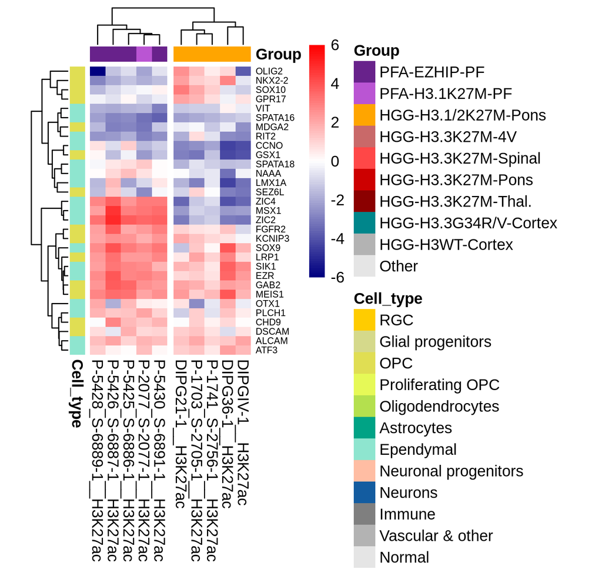

```r
# without H3.3K27Ms
samples_2 <- samples_1 %>% filter(Group %in% c("HGG-H3.1/2K27M-Pons",
                                               "PFA-EZHIP-PF",
                                               "PFA-H3.1K27M-PF")) %>%
    filter(bw %in% rownames(promoter_mat))

hm_fun(mat = t(log2(promoter_H3K27ac_mat_1)[samples_2$bw, discrim_features_hg]),
       cutree_cols = 2,
       filename = glue("{figout}/celltype_H3K27ac_discrim_heatmap2.png"),
       title = "Cell-type features discriminative of H3.1K27M HGG vs EZHIP PFA")
hm_fun(mat = t(log2(promoter_H3K27ac_mat_1)[samples_2$bw, discrim_features_hg]),
       cutree_cols = 2,
       filename = glue("{figout}/celltype_H3K27ac_discrim_heatmap2.pdf"),
       title = "Cell-type features discriminative of H3.1K27M HGG vs EZHIP PFA")

knitr::include_graphics(glue("{figout}/celltype_H3K27ac_discrim_heatmap2.png"))
```

# 8 Visualization of chromatin state @ COO features

## 8.1 Mouse reference data

First, set the features in the mm10 genome:

```r
opc_epen_features_mm10 <- list(
    GRanges("chr5",  37777685:37864531,   name = "Msx1"),
    GRanges("chr9",  91336804:91408070,   name = "Zic1/4"),
    GRanges("chr14", 122442135:122513576, name = "Zic2/5"),
    GRanges("chr16", 91197862:91254035,   name = "Olig2"),
    GRanges("chr2",  147137444:147241609, name = "Nkx2-2"),
    GRanges("chr15", 79149288:79189457,   name = "Sox10"))

params_mm <- map(opc_epen_features_mm10, ~ pgParams(chromstart = start(.x),
                                                    chromend = end(.x),
                                                    assembly = "mm10"))
names(params_mm) <- map(opc_epen_features_mm10, ~ .x$name)
```

Build the config file row-wise:

```r
mm10_config <- tribble(
    ~Data,      ~ID,               ~Ymax,  ~bw,
    "RNAseq",   "OPC scRNA",       151,    "data/Paired-Tag/Zhu_2021/bigwig/Paired-Tag_RNA_OPC.bw",
    "H3K27ac",  "OPC scH3K27ac",   112,    "data/Paired-Tag/Zhu_2021/bigwig/Paired-Tag_H3K27ac_OPC.bw",
    "H3K27me3", "OPC H3K27me3",    70,     "data/ChIPseq/references/Bartosovic_2021/Bulk/GSM4980053_P13556_1026_dedup.bw",
    "RNAseq",   "Epen. scRNA",     151,    "data/Paired-Tag/Zhu_2021/bigwig/Paired-Tag_RNA_Ependymal.bw",
    "H3K27ac",  "Epen. scH3K27ac", 112,    "data/Paired-Tag/Zhu_2021/bigwig/Paired-Tag_H3K27ac_Ependymal.bw"
) %>%
    mutate(bw = here(bw))

# sanity check
all(file.exists(mm10_config$bw))
```

```
## [1] TRUE
```

```r
# import chromHMM
chromhmm_epen <- rtracklayer::import(here("data/Paired-Tag/Zhu_2021/ChromHMM/cluster22_dense.bed"))
chromhmm_opc  <- rtracklayer::import(here("data/Paired-Tag/Zhu_2021/ChromHMM/cluster15_dense.bed"))
(palette_chromhmm <- as.data.frame(chromhmm_opc) %>% select(name, itemRgb) %>% distinct() %>% deframe())
```

```
##         8         4         3         1         7         2         6         5
## "#C8C8C8" "#00688A" "#04B1EE" "#B3EE39" "#727171" "#008B45" "#C30D19" "#956134"
```

Construct the figure:

```r
x_positions <- seq(0.5, 9, by = 1.25) + 1.5
y_positions <- seq(0.5, by = 0.4, length.out = nrow(mm10_config))
width <- 1

pageCreate(width = 11.5, height = 4, default.units = "inches")

# in this loop, for each region, we will
# 1. plot OPC bw
# 2. plot OPC ChromHMM
# 3. plot Epen. bw
# 4. plot Epen ChromHMM
# 5. plot genome labels
for (i in seq_along(params_mm)) {

    x_i <- x_positions[i]
    params_i <- params_mm[[i]]
    chrom <- as.character(seqnames(opc_epen_features_mm10[[i]]))
    # for the RNA & H3K27me3 bw files, chromsome names don't have the "chr" prefix...
    chroms_i <- unlist(map(mm10_config$Data,
                           ~ ifelse(.x %in% c("RNAseq", "H3K27me3"),
                                    as.numeric(stringr::str_extract(chrom, "[0-9]+")),
                                    chrom)))

    pwalk(list(mm10_config$bw[1:3], mm10_config$Data[1:3], mm10_config$Ymax[1:3], y_positions[1:3], chroms_i[1:3]),
          ~ pg_placeSignalAndLabel(data = ..1,
                                   color = palette_tracks[..2],
                                   range = c(0, ..3),
                                   y = ..4,
                                   x = x_i,
                                   chr = ..5,
                                   params = params_i,
                                   width = width,
                                   height = 0.35))

    plotRanges(chromhmm_opc, fill = chromhmm_opc$itemRgb, params = params_i, chrom = chrom, collapse = TRUE,
               x = x_i, y = "0.05b", height = 0.1, width = width)

    pwalk(list(mm10_config$bw[4:5], mm10_config$Data[4:5], mm10_config$Ymax[4:5], y_positions[4:5], chroms_i[4:5]),
          ~ pg_placeSignalAndLabel(data = ..1,
                                   color = palette_tracks[..2],
                                   range = c(0, ..3),
                                   y = ..4 + 0.3, # add a bit to account for chromHMM track
                                   x = x_i,
                                   chr = ..5,
                                   params = params_i,
                                   width = width,
                                   height = 0.35))

    plotRanges(chromhmm_epen, fill = chromhmm_epen$itemRgb, params = params_i, chrom = chrom, collapse = TRUE,
               x = x_i, y = "0.05b", height = 0.1, width = width)

    # place 0.1in below last plot
    plotGenomeLabel(params = params_i, chrom = chrom, scale = "Kb", x = x_i, y = "0.1b", length = width, fontsize = 8)

    plotGenes(params = params_i, chrom = chrom, x = x_i, y = "0.25b", height = 0.5, width = width,
              fontcolor = c("navy", "black"), fill = c("navy", "black"),
              stroke = 0.05,
              just = c("left", "top"), default.units = "inches")

}

# add data labels at left
pmap(list(c(mm10_config$ID[1:3], "OPC ChromHMM", mm10_config$ID[4:5], "Epen. ChromHMM"),
          c(y_positions[1:3], 1.5, y_positions[4:5] + 0.3, 2.7)),
     ~ plotText(label = ..1, fonsize = 3, fontcolor = "black",
                x = 0.2, y = ..2 + 0.2, just = c("left", "top"), default.units = "inches"))
```

```
## [[1]]
## text[text1]
##
## [[2]]
## text[text2]
##
## [[3]]
## text[text2]
##
## [[4]]
## text[text2]
##
## [[5]]
## text[text2]
##
## [[6]]
## text[text2]
##
## [[7]]
## text[text2]
```

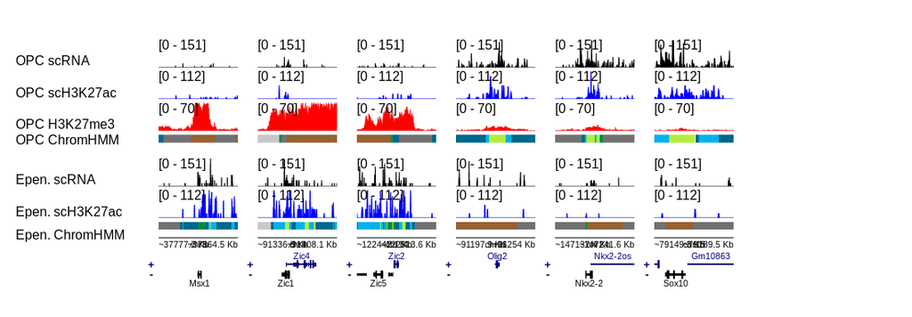

```r
pageGuideHide()
```

<sub>[figure @ *public/R-4/figures/03Amm10_tracks...*]</sub>

## 8.2 Human tumors / cell lines

Define the regions in the human genome:

```r
opc_epen_features_hg19 <- list(
    GRanges("chr4",  4836193:4890861,     name = "MSX1"),
    GRanges("chr3",  147066046:147179311, name = "ZIC1/4"),
    GRanges("chr13", 100595157:100661032, name = "ZIC2/5"),
    GRanges("chr21", 34372339:34427397,   name = "OLIG2"),
    GRanges("chr20", 21475155:21511204,   name = "NKX2-2"),
    GRanges("chr22", 38344095:38403785,   name = "SOX10"))

params_hg <- map(opc_epen_features_hg19, ~ pgParams(
    chrom = as.character(seqnames(.x)),
    chromstart = start(.x),
    chromend = end(.x),
    assembly = "hg19"))
names(params_hg) <- map(opc_epen_features_hg19, ~ .x$name)
```

Define the input samples:

```r
hg19_config <- meta_chip %>%
    filter(Group %in% c("HGG-H3.1/2K27M-Pons", "PFA-EZHIP-PF", "PFA-H3.1K27M-PF") &
               Factor == "H3K27ac" &
               grepl("Cell-of-origin", Analyses) &
               Material == "Tumor") %>%
    arrange(Group) %>%
    distinct(ID_paper, .keep_all = TRUE) %>%
    select(Data = Factor, ID_paper, Group, bw = Path_bw_internal) %>%
    mutate(Ymax = case_when(
        Group == "HGG-H3.1/2K27M-Pons" ~ 10,
        grepl("PFA", Group) ~ 25))

# sanity check
all(file.exists(hg19_config$bw))
```

```
## [1] TRUE
```

```r
# show IDs
print(hg19_config$ID_paper)
```

```
##  [1] "DIPG14p"       "DIPG21p"       "DIPG23p"       "DIPG32p"
##  [5] "DIPG33p"       "DIPG36p"       "DIPG38p"       "DIPG4p"
##  [9] "P-1703_S-2705" "P-1741_S-2756" "SF5609t"       "P-5425_S-6886"
## [13] "P-5426_S-6887" "P-5428_S-6889" "P-5430_S-6891" "P-2077_S-2077"
```

Construct the figure:

```r
x_positions <- seq(0.5, 9, by = 1.25) + 1.5
y_positions <- seq(0.5, by = 0.25, length.out = nrow(hg19_config))
width <- 1

pageCreate(width = 11.5, height = 6.5, default.units = "inches")

for (i in seq_along(params_hg)) {

    x_i <- x_positions[i]
    params_i <- params_hg[[i]]

    pwalk(list(hg19_config$bw, hg19_config$Group, hg19_config$Ymax, y_positions),
          ~ pg_placeSignalAndLabel2(data = ..1,
                                    color = palette_groups[..2],
                                    range = c(0, ..3),
                                    y = ..4,
                                    x = x_i,
                                    params = params_i,
                                    width = width,
                                    height = 0.2))

    plotGenomeLabel(params = params_i, scale = "Kb", x = x_i, y = "0.1b", length = width, fontsize = 8)

    plotGenes(params = params_i, x = x_i, y = "0.25b", height = 0.75, width = width,
              fontcolor = c("navy", "black"), fill = c("navy", "black"),
              stroke = 0.05,
              just = c("left", "top"), default.units = "inches")

}

# add data labels at left
pmap(list(hg19_config$ID, y_positions),
     ~ plotText(label = ..1, fonsize = 3, fontcolor = "black",
                x = 0.2, y = ..2 + 0.1, just = c("left", "top"), default.units = "inches"))
```

```
## list()
```

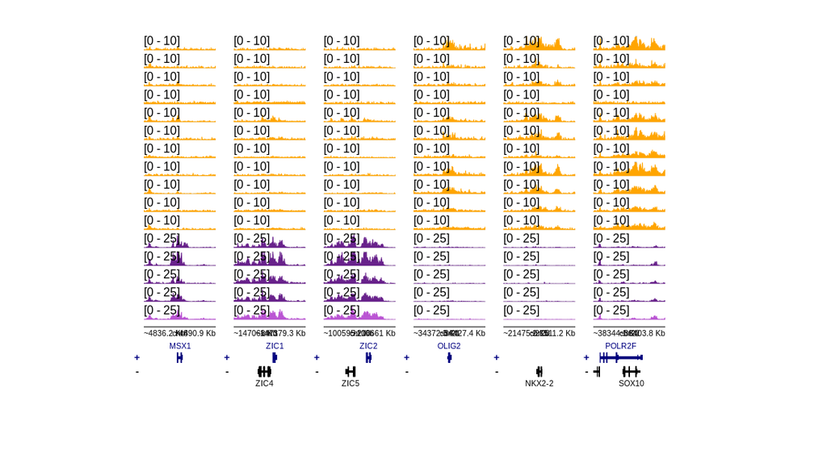

```r
pageGuideHide()
```

<sub>[figure @ *public/R-4/figures/03Ahg19_tracks...*]</sub>

# 9 Reproducibility

This document was last rendered on:

```
## 2022-07-28 14:53:09
```

The git repository and last commit:

```
## Local:    master /lustre06/project/6004736/sjessa/from_narval/HGG-oncohistones/public
## Remote:   master @ origin (git@github.com:fungenomics/HGG-oncohistones.git)
## Head:     [30e21fc] 2022-07-13: Update README
```

The random seed was set with `set.seed(100)`

The resources requested when this document was last rendered:

```
## #SBATCH --time=00:20:00
## #SBATCH --cpus-per-task=1
## #SBATCH --mem=10G
```

A project of the Kleinman Lab at McGill University, using the [rr](https://github.com/sjessa/rr/) reproducible research template.